# Jumlah Items tiap Product Scale

### **Hubungan Biaya Inventory terhadap Sales**

### Analisis Korelasi antara Inventory dan Sales

```r
cor_test <- cor.test(data$Inventory, data$Sales)
cor_test
```

```
##
##  Pearson's product-moment correlation
##
## data:  data$Inventory and data$Sales
## t = 22.465, df = 4246, p-value < 2.2e-16
## alternative hypothesis: true correlation is not equal to 0
## 95 percent confidence interval:
##  0.2987891 0.3525510
## sample estimates:
##       cor
## 0.3259335
```

Sebaliknya, jika p-value > 0,05, maka hubungan tersebut tidak signifikan secara statistik.

### Visualisasi antara Inventory dan Sales

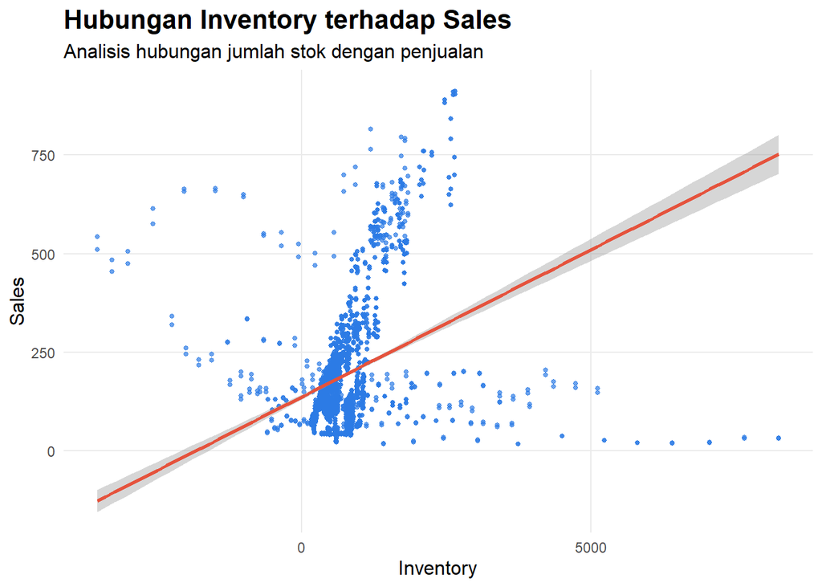

```r
ggplot(data, aes(x = Inventory, y = Sales)) +
  geom_point(color = "#2C7BE5", size = 1, alpha = 0.7) +
  geom_smooth(method = "lm", se = TRUE, color = "#E5533D", linewidth = 1) +
  ggtitle("Hubungan Inventory terhadap Sales") +
  labs(
    subtitle = "Analisis hubungan jumlah stok dengan penjualan",
    x = "Inventory",
    y = "Sales"
  ) +
  theme_minimal() +
  theme(
    plot.title = element_text(size = 16, face = "bold"),
    plot.subtitle = element_text(size = 12),
    axis.title = element_text(size = 12),
    panel.grid.minor = element_blank()
  )
```

Secara umum, visualisasi ini memberikan gambaran awal bahwa inventory memiliki keterkaitan dengan tingkat penjualan.

Secara keseluruhan, hasil analisis menunjukkan bahwa inventory memiliki hubungan dengan sales. Hal ini mengindikasikan bahwa ketersediaan stok barang berperan dalam menentukan tingkat penjualan.

Dalam konteks bisnis, inventory yang cukup memungkinkan perusahaan untuk memenuhi permintaan konsumen, sehingga dapat meningkatkan penjualan. Namun, inventory yang terlalu besar tidak selalu menjamin peningkatan sales, karena dapat menyebabkan overstock jika tidak diimbangi dengan permintaan yang tinggi.

Oleh karena itu, pengelolaan inventory yang optimal menjadi faktor penting dalam meningkatkan efisiensi dan performa penjualan.

### **Hubungan Biaya Sales terhadap Profit**

### Analisis Korelasi antara Sales dan Profit

```r
cor_test_sp <- cor.test(data$Sales, data$Profit)
cor_test_sp
```

```
##
##  Pearson's product-moment correlation
##
## data:  data$Sales and data$Profit
## t = 86.084, df = 4246, p-value < 2.2e-16
## alternative hypothesis: true correlation is not equal to 0
## 95 percent confidence interval:
##  0.7861073 0.8080289
## sample estimates:
##       cor
## 0.7973309
```

Hal ini berarti bahwa perubahan dalam nilai penjualan berkaitan secara nyata dengan perubahan profit yang dihasilkan.

### Visualisasi antara Sales dan Profit

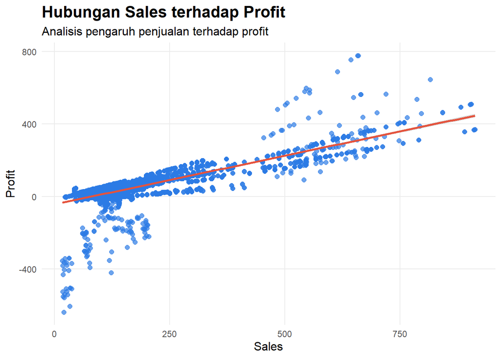

```r
ggplot(data, aes(x = Sales, y = Profit)) +
  geom_point(color = "#2C7BE5", size = 2, alpha = 0.7) +
  geom_smooth(method = "lm", se = TRUE, color = "#E5533D", linewidth = 1) +
  ggtitle("Hubungan Sales terhadap Profit") +
  labs(
    subtitle = "Analisis pengaruh penjualan terhadap profit",
    x = "Sales",
    y = "Profit"
  ) +
  theme_minimal() +
  theme(
    plot.title = element_text(size = 16, face = "bold"),
    plot.subtitle = element_text(size = 12),
    axis.title = element_text(size = 12),
    panel.grid.minor = element_blank()
  )
```

Garis tren yang ditambahkan menggunakan regresi linear menunjukkan arah hubungan yang meningkat. Hal ini berarti bahwa semakin tinggi nilai penjualan, maka profit cenderung meningkat.

Visualisasi ini memberikan gambaran awal bahwa sales memiliki keterkaitan dengan profit.

Secara keseluruhan, hasil analisis menunjukkan bahwa sales memiliki hubungan yang positif dengan profit. Hal ini mengindikasikan bahwa peningkatan penjualan merupakan faktor penting dalam meningkatkan keuntungan perusahaan.

Namun demikian, peningkatan sales tidak selalu diikuti oleh peningkatan profit secara proporsional. Hal ini disebabkan oleh adanya faktor lain seperti biaya produksi, biaya distribusi, serta biaya marketing yang dapat mempengaruhi besar kecilnya profit yang diperoleh.

Oleh karena itu, selain meningkatkan penjualan, perusahaan juga perlu memperhatikan efisiensi biaya agar profit dapat meningkat secara optimal.

## **Hubungan Biaya State terhadap Sales**

### Uji Anova antara State dan Sales

```r
anova_model <- aov(Sales ~ State, data = data)
summary(anova_model)
```

```
##               Df   Sum Sq Mean Sq F value Pr(>F)
## State         19 25317822 1332517   78.59 <2e-16 ***
## Residuals   4228 71688849   16956
## ---
## Signif. codes:  0 '***' 0.001 '**' 0.01 '*' 0.05 '.' 0.1 ' ' 1
```

Untuk menguji apakah perbedaan rata-rata penjualan antar state tersebut signifikan secara statistik, digunakan uji ANOVA (Analysis of Variance).

Jika p-value < 0,05, maka dapat disimpulkan bahwa terdapat perbedaan yang signifikan pada rata-rata sales antar state. Jika p-value > 0,05, maka tidak terdapat perbedaan yang signifikan.

### Visualisasi antara State dan Sales

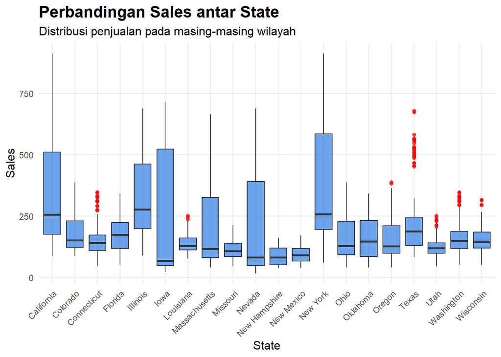

```r
ggplot(data, aes(x = State, y = Sales)) +
  geom_boxplot(fill = "#2C7BE5", alpha = 0.7, outlier.color = "red") +
  ggtitle("Perbandingan Sales antar State") +
  labs(
    subtitle = "Distribusi penjualan pada masing-masing wilayah",
    x = "State",
    y = "Sales"
  ) +
  theme_minimal() +
  theme(
    plot.title = element_text(size = 16, face = "bold"),
    plot.subtitle = element_text(size = 12),
    axis.title = element_text(size = 12),
    axis.text.x = element_text(angle = 45, hjust = 1),
    panel.grid.minor = element_blank()
  )
```

Berdasarkan boxplot yang ditampilkan, terlihat adanya perbedaan distribusi nilai sales antar state. Setiap boxplot merepresentasikan median, kuartil, serta sebaran data penjualan pada masing-masing wilayah.

Beberapa state menunjukkan median penjualan yang lebih tinggi dibandingkan state lainnya, yang mengindikasikan bahwa performa penjualan tidak merata di seluruh wilayah. Selain itu, terdapat variasi (penyebaran) data yang berbeda-beda, yang menunjukkan bahwa tingkat konsistensi penjualan juga bervariasi antar state.

Adanya outlier pada beberapa state menunjukkan bahwa terdapat nilai penjualan yang sangat tinggi atau rendah dibandingkan dengan data lainnya.

Secara keseluruhan, analisis menunjukkan bahwa terdapat perbedaan performa penjualan antar state. Hal ini mengindikasikan bahwa faktor geografis atau karakteristik wilayah dapat mempengaruhi tingkat penjualan produk.

Perbedaan ini dapat disebabkan oleh berbagai faktor, seperti tingkat permintaan konsumen, daya beli masyarakat, strategi pemasaran di masing-masing wilayah, serta tingkat persaingan pasar.

Oleh karena itu, perusahaan perlu mempertimbangkan strategi yang berbeda untuk setiap wilayah guna mengoptimalkan penjualan, seperti penyesuaian promosi, distribusi, dan pengelolaan stok barang.